# Delineamento em blocos casualizado

Eric Gorgens

1/17/2021

Nos experimentos em blocos casualizados (DBC), além do tratamento uma segunda fonte de variação controlada é inserida no modelo e é denominada de bloco. O bloco é inserido pelo analista para controlar uma variação esperada do ambiente, como por exemplo tipo de solo, insolação e outros. Assim a ANOVA contará com três fontes de variação: duas fontes de variação conhecidas determinada pelo tratamento e pelo bloco, e uma fonte de variação desconhecida determinada pelo resíduo. Vale destacar, que no DBC, não há interesse pela interação do bloco com o tratamento, sendo o bloco apenas para controlar uma possível variação sobre os tratamentos induzida por uma possível variação do ambiente. O modelo estatístico do delineamento em blocos casualizados é:

$$Y = Xmed + BLOCO + TRAT + Erro$$

A análise começa pela determinação das somas de quadrados total, composta pela soma de quadrados do tratamento, pela soma de quadrados do bloco e pela soma de quadrados do resíduo. Em seguida, calculam-se os quadrados médios do tratamento e do resíduo e o valor da estatística F. Se F calculado for superior ao F tabelado, assume-se que existe um efeito devido aos tratamentos, ao passo que se F calculado for inferior ao F tabelado, não há evidências suficientes para rejeitar a hipótese nula, aceitando-se a hipótese de que não existe efeito dos tratamentos.

Embora em alguns softwares o teste F para o bloco seja realizado, o mesmo não é necessário. O utilidade do bloco é é apenas isolar uma possível variação atribuída ao ambiente. Uma vez que tenha optado pelo uso do bloco, é irrelevante encontrar sua significância (ou não significância) , uma vez que não será alterado o design da análise. Sendo o efeito dos tratamentos significativo, realiza-se o desdobramento do efeito dos tratamentos através de um teste de médias se os tratamentos forem qualitativos, ou uma análise de regressão se os tratamentos forem quantitativos.

Para a análise de experimentos em blocos casualizados, como não há no modelo estatístico a influência da interação, utiliza-se o pacote ExpDes.pt tanto para o caso balanceado, quanto para o desbalanceado.

## O caso balanceado

Para exemplificar o caso balanceado, será analisado um estudo sobre a influência de duas intensidades de desbaste no diâmetro de árvores. Os desbastes foram repetidos em 4 parcelas para cada um dos cinco blocos. Os blocos foram considerados para isolar o efeito dos diferentes tipos de solo. Os dados podem ser resumidos através dos seguintes tópicos:

- Tratamento: 2 intensidades de desbaste (30% e 50%)
- 5 Blocos
- 4 repetições
- Variável de interesse: diâmetro

Dados de delineamento em blocos casualizado

| desbaste | bloco | rep | diametro |
| --- | --- | --- | --- |
| 30 | 1 | 1 | 28.37041 |
| 30 | 1 | 2 | 29.28010 |
| 30 | 1 | 3 | 30.84926 |
| 30 | 1 | 4 | 27.89227 |
| 30 | 2 | 1 | 20.38856 |
| 30 | 2 | 2 | 21.47290 |
| 30 | 2 | 3 | 24.39744 |
| 30 | 2 | 4 | 24.65861 |
| 30 | 3 | 1 | 23.79856 |
| 30 | 3 | 2 | 25.69388 |
| 30 | 3 | 3 | 24.45922 |
| 30 | 3 | 4 | 27.94071 |
| 30 | 4 | 1 | 28.05501 |
| 30 | 4 | 2 | 26.42934 |
| 30 | 4 | 3 | 23.09124 |
| 30 | 4 | 4 | 22.54273 |
| 30 | 5 | 1 | 32.73052 |
| 30 | 5 | 2 | 29.17538 |
| 30 | 5 | 3 | 29.94747 |
| 30 | 5 | 4 | 29.35810 |
| 50 | 1 | 1 | 31.20701 |
| 50 | 1 | 2 | 40.85273 |
| 50 | 1 | 3 | 33.66891 |
| 50 | 1 | 4 | 33.15001 |
| 50 | 2 | 1 | 34.03869 |
| 50 | 2 | 2 | 36.24517 |
| 50 | 2 | 3 | 35.49081 |
| 50 | 2 | 4 | 31.58952 |
| 50 | 3 | 1 | 31.92634 |
| 50 | 3 | 2 | 28.82107 |
| 50 | 3 | 3 | 32.18963 |
| 50 | 3 | 4 | 31.55686 |
| 50 | 4 | 1 | 31.11534 |
| 50 | 4 | 2 | 31.05093 |
| 50 | 4 | 3 | 34.69215 |
| 50 | 4 | 4 | 32.95378 |
| 50 | 5 | 1 | 25.26880 |
| 50 | 5 | 2 | 30.48375 |
| 50 | 5 | 3 | 31.73922 |
| 50 | 5 | 4 | 26.21619 |

O primeiro passo é importar o arquivo csv contendo os resultados do experimento para dentro do R. Esta tarefa pode ser realizada através do seguinte comando:

```r
dbc1 = read.csv("./data/Experimento DBC 1.csv")
```

Antes de partir para a análise, é fundamental explorar os dados de forma gráfica para conhecer melhor os dados e antecipar o resultado da análise estatística. A construção do gráfico ajuda na compreensão do fenômeno estudado e na validação da análise estatística escolhida. Por se tratar de um experimento com o tratamento formado por níveis qualitativos, recomenda-se o uso do boxplot().

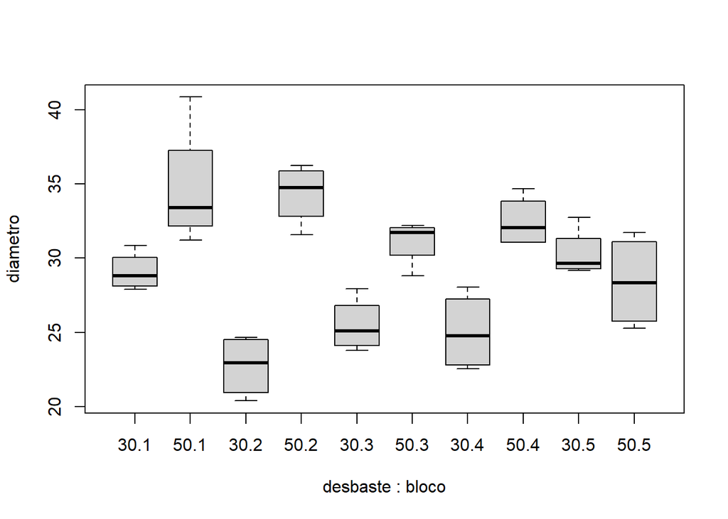

```r
boxplot(data = dbc1, diametro ~ desbaste/bloco)
```

Note que os rótulo do eixo X são compostos pela união no desbaste e do bloco. Pode ser que dependendo do espaço disponível alguns rótulos sejam omitidos, mas ele devem ser lidos alternadamente, uma caixa para 30.1, outra para 50.1, depois 30.2, seguido de 50.2 e assim por diante.

Os tratamentos podem ser analisados isoladamente em relação a cada bloco, utilizando um filtro para escolher qual bloco considerar.

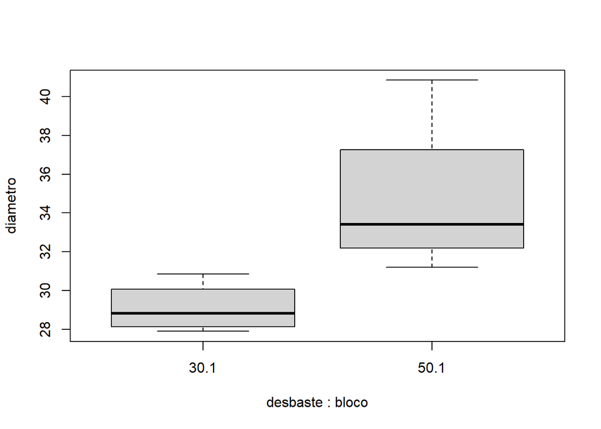

```r
# Para bloco igual a 1
boxplot(data = dbc1[dbc1$bloco == 1,], diametro~desbaste/bloco)
```

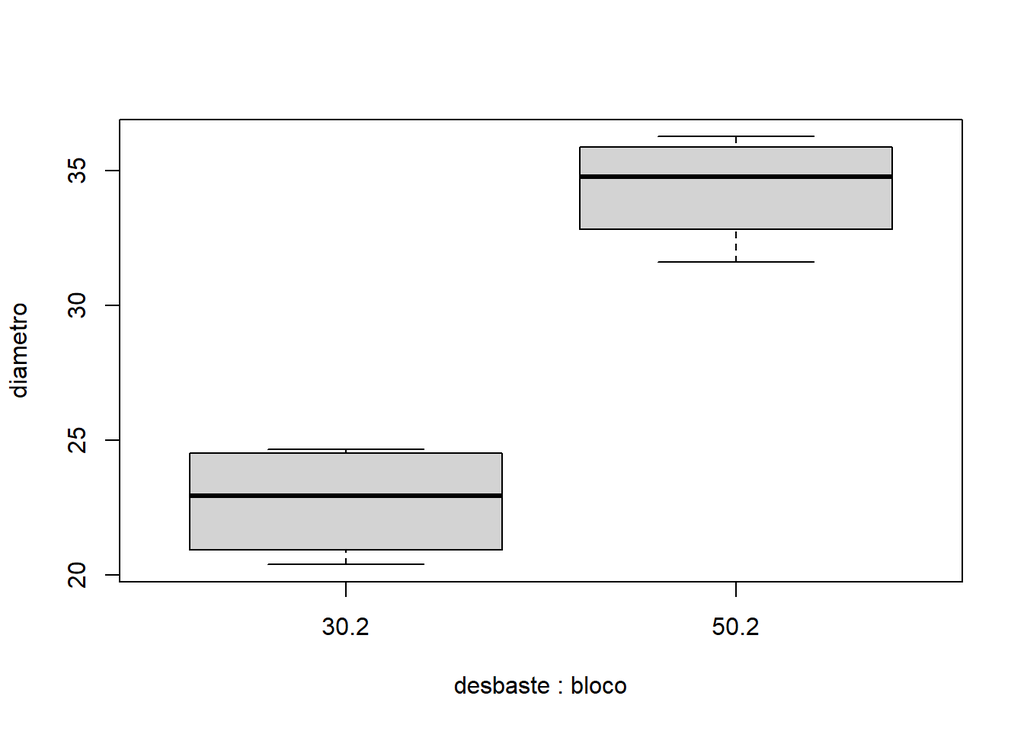

```r
# Para bloco igual a 2
boxplot(data = dbc1[dbc1$bloco == 2,], diametro~desbaste/bloco)
```

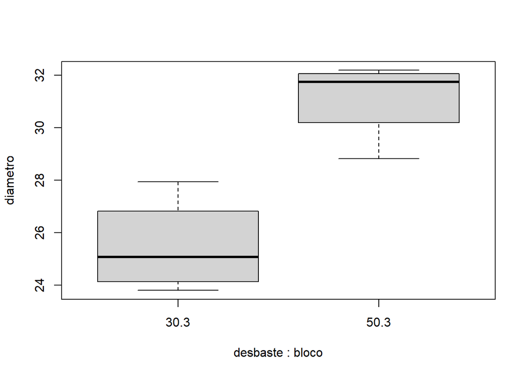

```r
# Para bloco igual a 3
boxplot(data = dbc1[dbc1$bloco == 3,], diametro~desbaste/bloco)
```

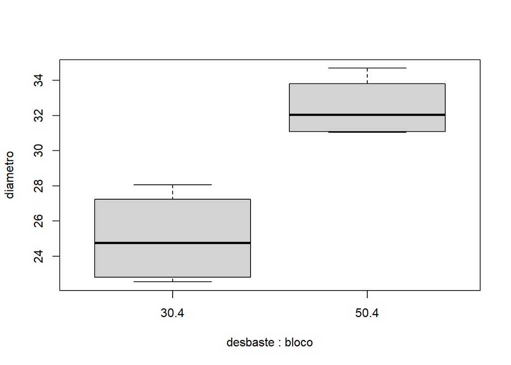

```r
# Para bloco igual a 4
boxplot(data = dbc1[dbc1$bloco == 4,], diametro~desbaste/bloco)
```

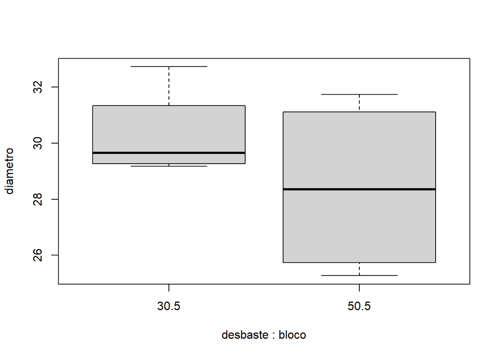

```r
# Para bloco igual a 5
boxplot(data = dbc1[dbc1$bloco == 5,], diametro~desbaste/bloco)
```

Pelo gráfico obtido, é razoável esperar que haja diferenças significativas entre as intensidades de desbaste (30% e 50%), pois existe um distanciamento entre os interquartis especialmente nos blocos 1 e 2. Também é possível esperar que não haja um efeito significativo dos blocos. Assim, espera-se que a análise estatística do experimento corrobore a conclusão empírica baseada no interpretação do gráfico.

Com a função dbc() do pacote ExpDes.pt será possível realizar toda a análise de um experimento de delineamento em blocos casualizados, inclusive desdobramentos. Toda função no R tem uma sintaxe que pode ser consultada digitando no console ? seguido do nome da função:

```r
?dbc
```

Nas informações sobre a função ?dbc, você verá que a sintaxe básica da função dbc() é:

```r
dbc(trat, bloco, resp, quali = TRUE, mcomp = "tukey",
    sigT = 0.05, sigF = 0.05)
```

A análise do experimento em questão pode ser então realizada pelo comando:

```r
require(ExpDes.pt)
dbc(dbc1$desbaste, dbc1$bloco, dbc1$diametro, hvar='han')
```

```
## ------------------------------------------------------------------------
## Quadro da analise de variancia
## ------------------------------------------------------------------------
##            GL     SQ QM      Fc    Pr>Fc
## Tratamento  1 323.34  4 30.4546 0.000004
## Bloco       4  69.49  3  1.6363 0.187727
## Residuo    34 360.98  2
## Total      39 753.80  1
## ------------------------------------------------------------------------
## CV = 11.09 %
##
## ------------------------------------------------------------------------
## Teste de normalidade dos residuos
## valor-p:  0.9155415
## De acordo com o teste de Shapiro-Wilk a 5% de significancia, os residuos podem ser considerados normais.
## ------------------------------------------------------------------------
##
## ------------------------------------------------------------------------
## Teste de homogeneidade de variancia
## valor-p:  0.3001718
## De acordo com o teste de han a 5% de significancia, as variancias podem ser consideradas homogeneas.
## ------------------------------------------------------------------------
##
## Teste de Tukey
## ------------------------------------------------------------------------
## Grupos Tratamentos Medias
## a     50      32.21285
##  b    30      26.52659
## ------------------------------------------------------------------------
```

A interpretação da saída de um delineamento em blocos casualizados é muito parecido com os experimento em DIC. A inclusão do bloco como fonte de variação, não trás nenhuma implicação já que o bloco visa apenas isolar um potencial efeito do ambiente não controlado durante a instalação do experimento.

Neste primeiro exemplo, os resíduos apresentaram normalidade e o efeito dos tratamentos foi significativo. Como existem apenas dois tratamento, a significância do teste F já é conclusivo. De qualquer forma, a função dbc() realiza também um teste de médias que apenas reforça o resultado do teste F, indicando que o grupo a obteve média maior que o grupo b.

## O caso desbalanceado

Embora o delineamento em blocos casualizados, tenha além do tratamento, o efeito do bloco, estes são analisados de forma independente sem considerar a interação entre eles. A rigor, a definição de blocos visa apenas controlar uma fonte de variação não controlada pelo experimento, e não inferir sobre seu efeito. Desta forma, por não haver interação, o caso de DBC desbalanceado pode ser analisado através da ANOVA do Tipo I.

Neste exemplo, usaremos o mesmo exemplo anterior, mas assumindo que foi perdida uma parcela devido à um incêndio: a repetição 1, do bloco 2 do tratamento intensidade de desbaste de 30%:

- Tratamento: 2 intensidades de desbaste
- 5 Blocos
- 4 repetições
- Variável de interesse: diâmetro
- Parcela perdida: Tratamento 30, Bloco 2, Repetição 1.

Dados de delineamento em blocos casualizado

| desbaste | bloco | rep | diametro |
| --- | --- | --- | --- |
| 30 | 1 | 1 | 28.37041 |
| 30 | 1 | 2 | 29.28010 |
| 30 | 1 | 3 | 30.84926 |
| 30 | 1 | 4 | 27.89227 |
| 30 | 2 | 2 | 21.47290 |
| 30 | 2 | 3 | 24.39744 |
| 30 | 2 | 4 | 24.65861 |
| 30 | 3 | 1 | 23.79856 |
| 30 | 3 | 2 | 25.69388 |
| 30 | 3 | 3 | 24.45922 |
| 30 | 3 | 4 | 27.94071 |
| 30 | 4 | 1 | 28.05501 |
| 30 | 4 | 2 | 26.42934 |
| 30 | 4 | 3 | 23.09124 |
| 30 | 4 | 4 | 22.54273 |
| 30 | 5 | 1 | 32.73052 |
| 30 | 5 | 2 | 29.17538 |
| 30 | 5 | 3 | 29.94747 |
| 30 | 5 | 4 | 29.35810 |
| 50 | 1 | 1 | 31.20701 |
| 50 | 1 | 2 | 40.85273 |
| 50 | 1 | 3 | 33.66891 |
| 50 | 1 | 4 | 33.15001 |
| 50 | 2 | 1 | 34.03869 |
| 50 | 2 | 2 | 36.24517 |
| 50 | 2 | 3 | 35.49081 |
| 50 | 2 | 4 | 31.58952 |
| 50 | 3 | 1 | 31.92634 |
| 50 | 3 | 2 | 28.82107 |
| 50 | 3 | 3 | 32.18963 |
| 50 | 3 | 4 | 31.55686 |
| 50 | 4 | 1 | 31.11534 |
| 50 | 4 | 2 | 31.05093 |
| 50 | 4 | 3 | 34.69215 |
| 50 | 4 | 4 | 32.95378 |
| 50 | 5 | 1 | 25.26880 |
| 50 | 5 | 2 | 30.48375 |
| 50 | 5 | 3 | 31.73922 |
| 50 | 5 | 4 | 26.21619 |

O primeiro passo é importar o arquivo csv contendo os resultados do experimento para dentro do R. Esta tarefa pode ser realizada através do seguinte comando:

```r
dbc2 = read.csv("./data/Experimento DBC 2.csv")
```

Mesmo no caso desbalanceado, a análise gráfica é fundamental e deve preceder qualquer análise estatística:

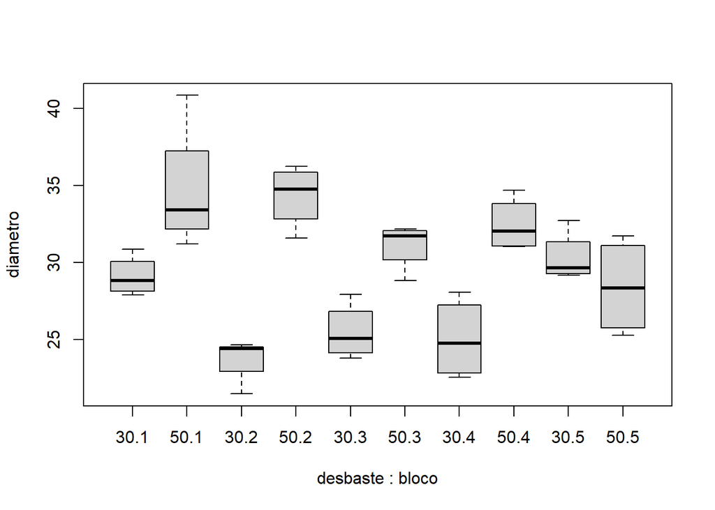

```r
boxplot(data = dbc2, diametro ~ desbaste/bloco)
```

Os tratamentos podem ser analisados isoladamente em relação a cada bloco, utilizando um filtro para escolher qual bloco considerar.

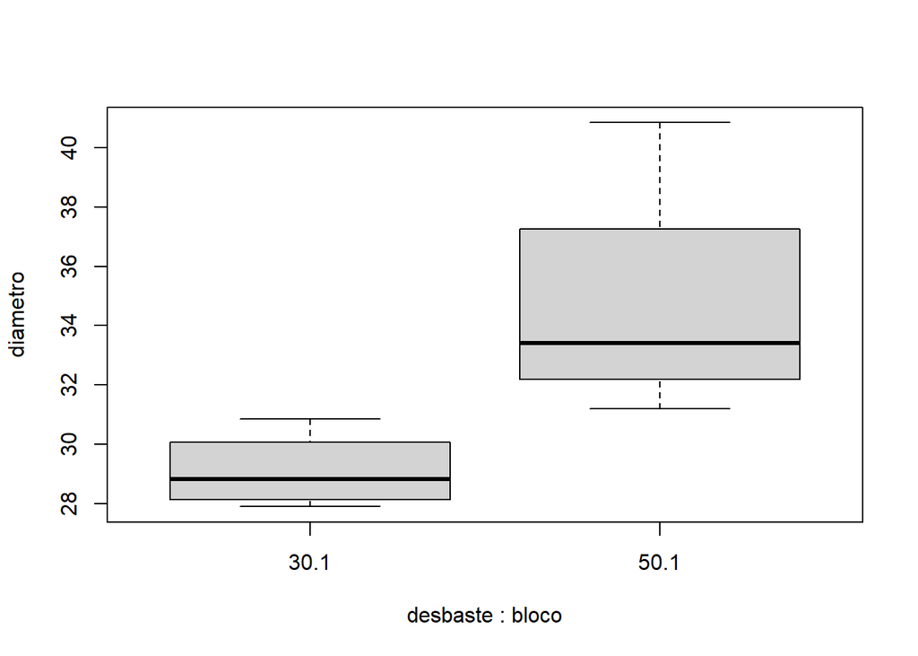

```r
# Para bloco igual a 1
boxplot(data = dbc2[dbc2$bloco == 1,], diametro~desbaste/bloco)
```

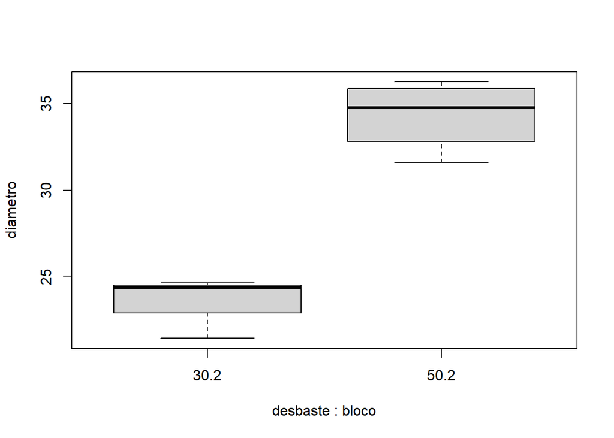

```r
# Para bloco igual a 2
boxplot(data = dbc2[dbc2$bloco == 2,], diametro~desbaste/bloco)
```

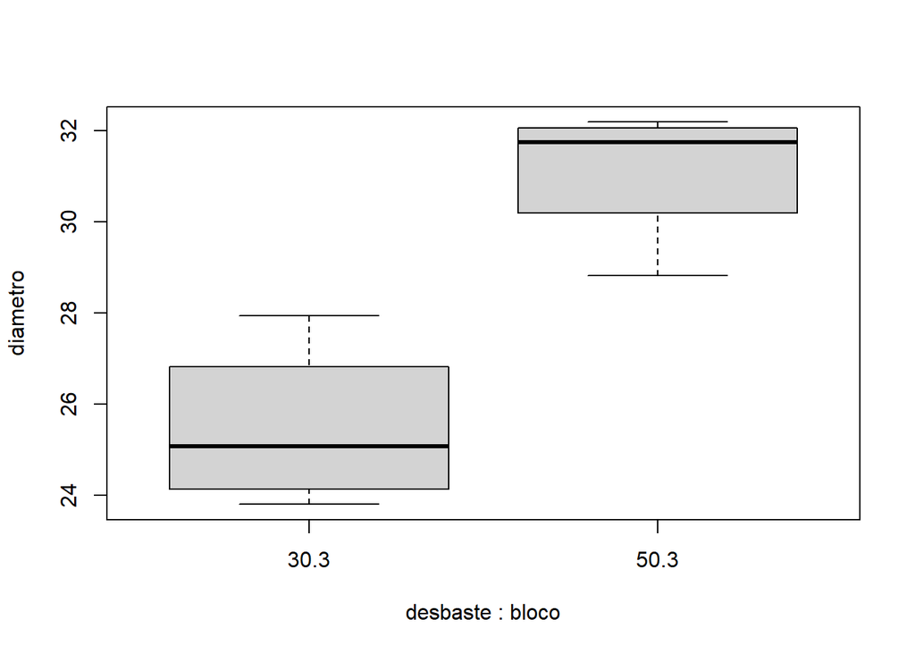

```r
# Para bloco igual a 3
boxplot(data = dbc2[dbc2$bloco == 3,], diametro~desbaste/bloco)
```

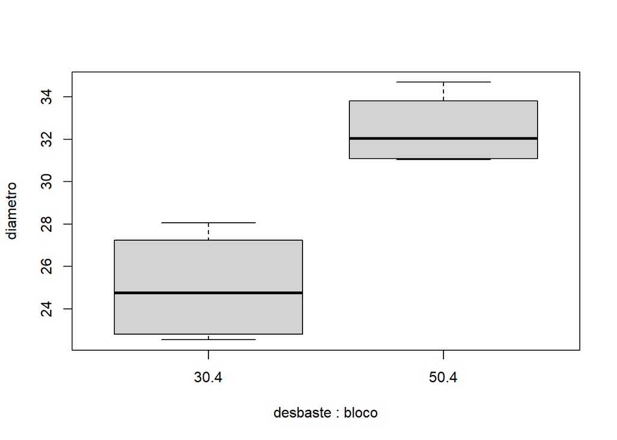

```r
# Para bloco igual a 4
boxplot(data = dbc2[dbc2$bloco == 4,], diametro~desbaste/bloco)
```

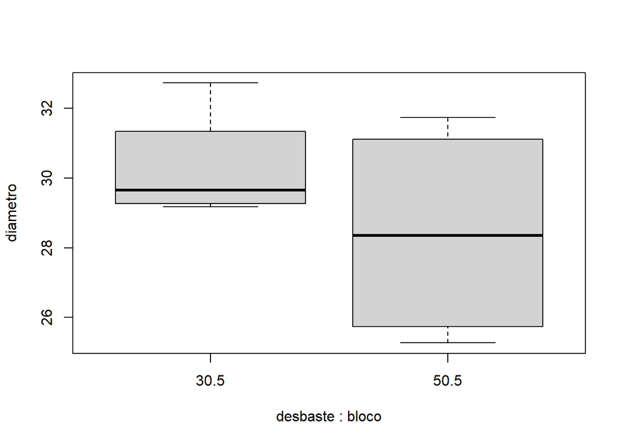

```r
# Para bloco igual a 5
boxplot(data = dbc2[dbc2$bloco == 5,], diametro~desbaste/bloco)
```

Como já discutido anteriormente, por não haver cálculo de interação entre fontes de variação, o DBC pode ser analisado usando o pacote padrão ExpDes.pt e sua função dbc():

```r
require(ExpDes.pt)
dbc(dbc2$desbaste, dbc2$bloco, dbc2$diametro, hvar='han')
```

```
## ------------------------------------------------------------------------
## Quadro da analise de variancia
## ------------------------------------------------------------------------
##            GL     SQ QM      Fc    Pr>Fc
## Tratamento  1 280.26  3 28.2071 0.000007
## Bloco       4  62.92  2  1.5832 0.201872
## Residuo    33 327.89  4
## Total      38 671.07  1
## ------------------------------------------------------------------------
## CV = 10.65 %
##
## ------------------------------------------------------------------------
## Teste de normalidade dos residuos
## valor-p:  0.9523324
## De acordo com o teste de Shapiro-Wilk a 5% de significancia, os residuos podem ser considerados normais.
## ------------------------------------------------------------------------
##
## ------------------------------------------------------------------------
## Teste de homogeneidade de variancia
## valor-p:  0.3579419
## De acordo com o teste de han a 5% de significancia, as variancias podem ser consideradas homogeneas.
## ------------------------------------------------------------------------
##
## Teste de Tukey
## ------------------------------------------------------------------------
## Grupos Tratamentos Medias
## a     50      32.21285
##  b    30      26.84964
## ------------------------------------------------------------------------
```

O teste de Shapiro-Wilk não aponta evidências para rejeitar a hipótese de normalidade de resíduos e portanto o modelo estatístico de blocos casualizados é considerado adequado.